# Multiple Correspondence Analysis

Dataset tea2

This dataset contains 300 individuals and 89 variables.

### 1. Study of the outliers

The analysis of the graphs does not detect any outlier.

### 2. Inertia distribution

The inertia of the first dimensions shows if there are strong relationships between variables and suggests the number of dimensions that should be studied.

The first two dimensions of MCA express **11.13%** of the total dataset inertia ; that means that 11.13% of the individuals (or variables) cloud total variability is explained by the plane. This is a very small percentage and the first plane represents a small part of the data variability. This value is greater than the reference value that equals **7.18%**, the variability explained by this plane is thus significant (the reference value is the 0.95-quantile of the inertia percentages distribution obtained by simulating 611 data tables of equivalent size on the basis of a uniform distribution).

From these observations, it is important to also interpret the dimensions greater or equal to the third one.

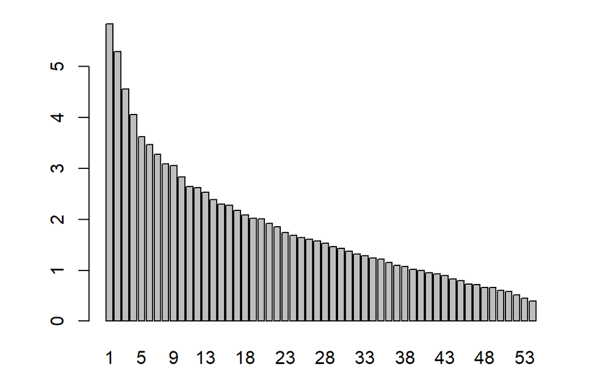

**Figure 2 - Decomposition of the total inertia on the components of the MCA**

An estimation of the right number of axis to interpret suggests to restrict the analysis to the description of the first 13 axis. These axis present an amount of inertia greater than those obtained by the 0.95-quantile of random distributions (46.86% against 38.76%). This observation suggests that only these axis are carrying a real information. As a consequence, the description will stand to these axis.

### 3. Description of the plane 1:2

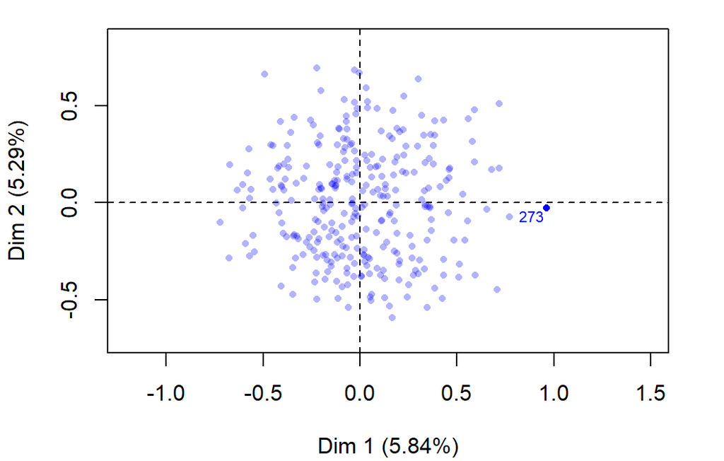

**Figure 3.1 - Individuals factor map (MCA)** *The labeled individuals are those with the higher contribution to the plane construction.*

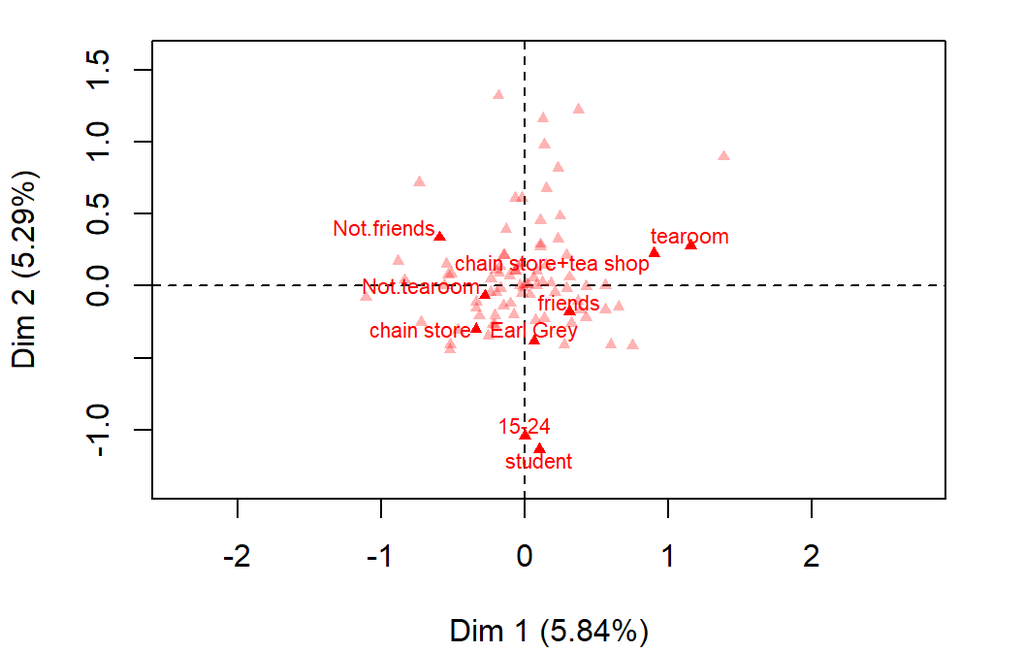

**Figure 3.2 - Variables factor map (MCA)** *The labeled variables are those the best shown on the plane.*

The **dimension 1** opposes individuals such as *273* (to the right of the graph, characterized by a strongly positive coordinate on the axis) to individuals characterized by a strongly negative coordinate on the axis (to the left of the graph).

The group 1 (characterized by a positive coordinate on the axis) is sharing :

- high frequency for factors like *SPC=non-worker*, *age_Q=+60*, *how=unpackaged*, *sugar=No.sugar*, *price=p_upscale*, *Tea=black*, *where=tea shop*, *where=chain store+tea shop*, *age_Q=45-59* and *Sport=Not.sportsman* (factors are sorted from the most common).
- low frequency for factors like *age_Q=15-24*, *where=chain store*, *SPC=student*, *sugar=sugar*, *Tea=Earl Grey*, *Sport=sportsman*, *tearoom=Not.tearoom*, *how=tea bag*, *diuretic=Not.diuretic* and *sophisticated=Not.sophisticated* (factors are sorted from the rarest).

The group in which the individual *273* stands (characterized by a positive coordinate on the axis) is sharing :

- high frequency for factors like *age_Q=15-24*, *SPC=student*, *Tea=Earl Grey*, *sex=F*, *friends=friends*, *pub=pub*, *relaxing=relaxing*, *always=always*, *friendliness=friendliness* and *frequency=+2/day* (factors are sorted from the most common).
- low frequency for factors like *SPC=non-worker*, *age_Q=+60*, *sex=M*, *friends=Not.friends*, *pub=Not.pub*, *relaxing=No.relaxing*, *always=Not.always*, *friendliness=Not.friendliness*, *evening=Not.evening* and *where=tea shop* (factors are sorted from the rarest).

The group 3 (characterized by a negative coordinate on the axis) is sharing :

- high frequency for factors like *tea.time=Not.tea time*, *sex=M*, *friendliness=Not.friendliness*, *where=chain store*, *friends=Not.friends*, *tearoom=Not.tearoom*, *frequency=1/day*, *dinner=dinner*, *feminine=Not.feminine* and *pub=Not.pub* (factors are sorted from the most common).
- low frequency for factors like *frequency=+2/day*, *tea.time=tea time*, *sex=F*, *where=chain store+tea shop*, *friendliness=friendliness*, *friends=friends*, *tearoom=tearoom*, *dinner=Not.dinner*, *feminine=feminine* and *pub=pub* (factors are sorted from the rarest).

The **dimension 2** opposes individuals characterized by a strongly positive coordinate on the axis (to the top of the graph) to individuals such as *273* (to the bottom of the graph, characterized by a strongly negative coordinate on the axis).

The group 1 (characterized by a positive coordinate on the axis) is sharing :

- high frequency for factors like *SPC=non-worker*, *age_Q=+60*, *how=unpackaged*, *sugar=No.sugar*, *price=p_upscale*, *Tea=black*, *where=tea shop*, *where=chain store+tea shop*, *age_Q=45-59* and *Sport=Not.sportsman* (factors are sorted from the most common).
- low frequency for factors like *age_Q=15-24*, *where=chain store*, *SPC=student*, *sugar=sugar*, *Tea=Earl Grey*, *Sport=sportsman*, *tearoom=Not.tearoom*, *how=tea bag*, *diuretic=Not.diuretic* and *sophisticated=Not.sophisticated* (factors are sorted from the rarest).

The group in which the individual *273* stands (characterized by a negative coordinate on the axis) is sharing :

- high frequency for factors like *age_Q=15-24*, *SPC=student*, *Tea=Earl Grey*, *sex=F*, *friends=friends*, *pub=pub*, *relaxing=relaxing*, *always=always*, *friendliness=friendliness* and *frequency=+2/day* (factors are sorted from the most common).
- low frequency for factors like *SPC=non-worker*, *age_Q=+60*, *sex=M*, *friends=Not.friends*, *pub=Not.pub*, *relaxing=No.relaxing*, *always=Not.always*, *friendliness=Not.friendliness*, *evening=Not.evening* and *where=tea shop* (factors are sorted from the rarest).

### 4. Description of the plane 3:4

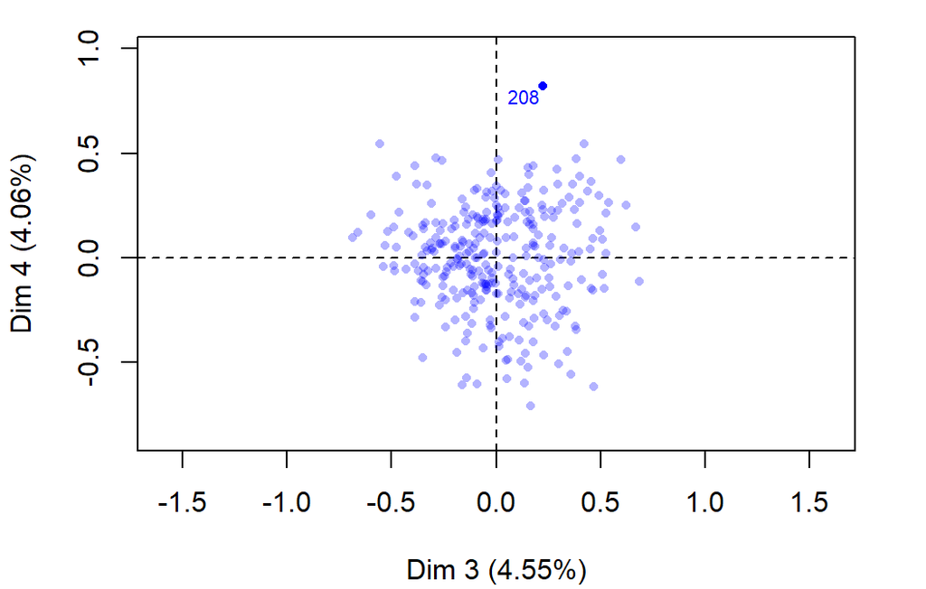

**Figure 4.1 - Individuals factor map (MCA)** *The labeled individuals are those with the higher contribution to the plane construction.*

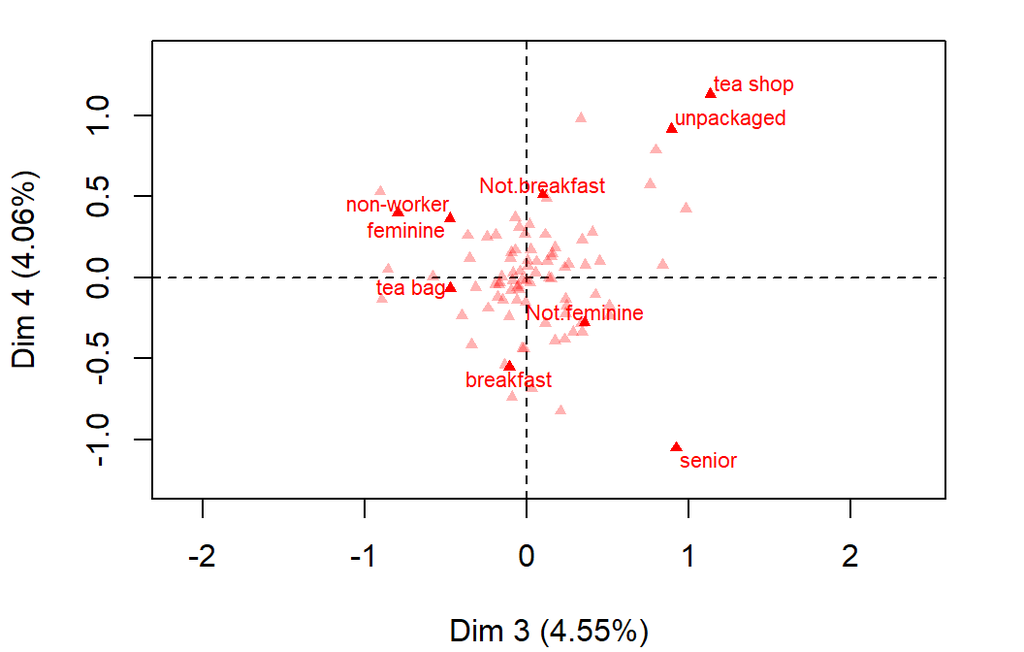

**Figure 4.2 - Variables factor map (MCA)** *The labeled variables are those the best shown on the plane.*

The group 1 (characterized by a positive coordinate on the axis) is sharing :

- high frequency for factors like *SPC=senior*, *feminine=Not.feminine*, *sophisticated=Not.sophisticated*, *breakfast=breakfast*, *frequency=1/day*, *sex=M*, *Sport=sportsman*, *How=milk*, *where=chain store+tea shop* and *friendliness=Not.friendliness* (factors are sorted from the most common).
- low frequency for factors like *feminine=feminine*, *sophisticated=sophisticated*, *breakfast=Not.breakfast*, *SPC=non-worker*, *sex=F*, *where=tea shop*, *age_Q=+60*, *how=unpackaged*, *Sport=Not.sportsman* and *work=Not.work* (factors are sorted from the rarest).

The group 2 (characterized by a positive coordinate on the axis) is sharing :

- high frequency for factors like *how=unpackaged*, *where=tea shop*, *age_Q=25-34*, *price=p_upscale*, *breakfast=Not.breakfast*, *dinner=dinner*, *feminine=Not.feminine*, *slimming=No.slimming*, *tearoom=tearoom* and *healthy=Not.healthy* (factors are sorted from the most common).
- low frequency for factors like *how=tea bag*, *price=p_branded*, *breakfast=breakfast*, *where=chain store*, *dinner=Not.dinner*, *age_Q=15-24*, *feminine=feminine*, *age_Q=+60*, *slimming=slimming* and *tearoom=Not.tearoom* (factors are sorted from the rarest).

The **dimension 4** opposes individuals such as *208* (to the top of the graph, characterized by a strongly positive coordinate on the axis) to individuals characterized by a strongly negative coordinate on the axis (to the bottom of the graph).

The group in which the individual *208* stands (characterized by a positive coordinate on the axis) is sharing :

- high frequency for factors like *feminine=feminine*, *SPC=non-worker*, *sex=F*, *age_Q=+60*, *how=tea bag*, *Sport=Not.sportsman*, *price=p_branded*, *slimming=slimming*, *work=Not.work* and *age_Q=15-24* (factors are sorted from the most common).
- low frequency for factors like *feminine=Not.feminine*, *sex=M*, *SPC=senior*, *age_Q=25-34*, *Sport=sportsman*, *slimming=No.slimming*, *work=work*, *how=tea bag+unpackaged*, *sophisticated=Not.sophisticated* and *SPC=middle* (factors are sorted from the rarest).

The group 2 (characterized by a positive coordinate on the axis) is sharing :

- high frequency for factors like *how=unpackaged*, *where=tea shop*, *age_Q=25-34*, *price=p_upscale*, *breakfast=Not.breakfast*, *dinner=dinner*, *feminine=Not.feminine*, *slimming=No.slimming*, *tearoom=tearoom* and *healthy=Not.healthy* (factors are sorted from the most common).
- low frequency for factors like *how=tea bag*, *price=p_branded*, *breakfast=breakfast*, *where=chain store*, *dinner=Not.dinner*, *age_Q=15-24*, *feminine=feminine*, *age_Q=+60*, *slimming=slimming* and *tearoom=Not.tearoom* (factors are sorted from the rarest).

The group 3 (characterized by a negative coordinate on the axis) is sharing :

- high frequency for factors like *SPC=senior*, *feminine=Not.feminine*, *sophisticated=Not.sophisticated*, *breakfast=breakfast*, *frequency=1/day*, *sex=M*, *Sport=sportsman*, *How=milk*, *where=chain store+tea shop* and *friendliness=Not.friendliness* (factors are sorted from the most common).
- low frequency for factors like *feminine=feminine*, *sophisticated=sophisticated*, *breakfast=Not.breakfast*, *SPC=non-worker*, *sex=F*, *where=tea shop*, *age_Q=+60*, *how=unpackaged*, *Sport=Not.sportsman* and *work=Not.work* (factors are sorted from the rarest).

### 5. Description of the plane 5:6

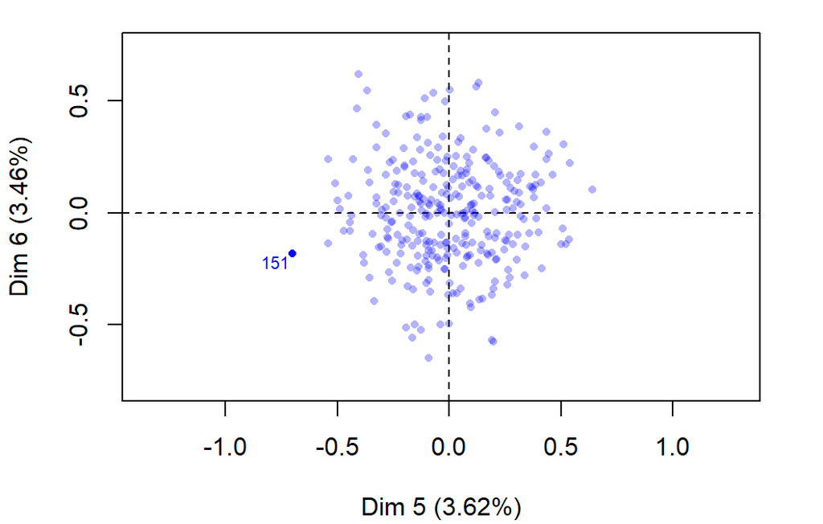

**Figure 5.1 - Individuals factor map (MCA)** *The labeled individuals are those with the higher contribution to the plane construction.*

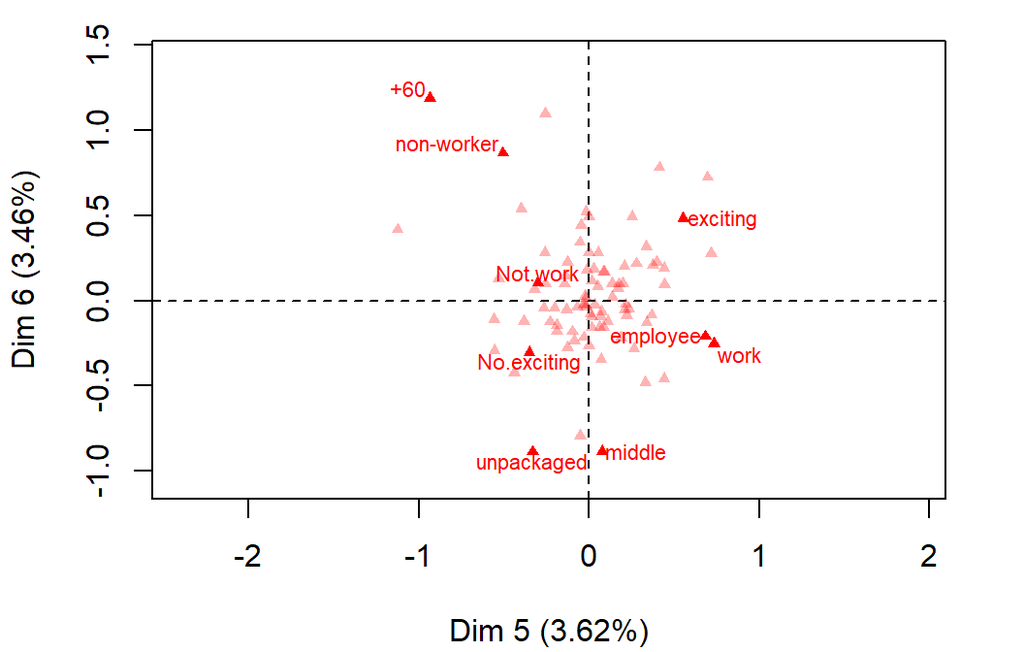

**Figure 5.2 - Variables factor map (MCA)** *The labeled variables are those the best shown on the plane.*

The **dimension 5** opposes individuals characterized by a strongly positive coordinate on the axis (to the right of the graph) to individuals such as *151* (to the left of the graph, characterized by a strongly negative coordinate on the axis).

The group 1 (characterized by a positive coordinate on the axis) is sharing :

- high frequency for factors like *age_Q=45-59*, *healthy=healthy*, *how=unpackaged*, *SPC=middle*, *exciting=No.exciting*, *sugar=No.sugar*, *resto=Not.resto*, *sophisticated=sophisticated*, *work=work* and *always=always* (factors are sorted from the most common).
- low frequency for factors like *SPC=non-worker*, *healthy=Not.healthy*, *sugar=sugar*, *exciting=exciting*, *age_Q=+60*, *resto=resto*, *sophisticated=Not.sophisticated*, *work=Not.work*, *always=Not.always* and *age_Q=15-24* (factors are sorted from the rarest).

The group 2 (characterized by a positive coordinate on the axis) is sharing :

- high frequency for factors like *exciting=exciting*, *work=work*, *SPC=employee*, *Tea=Earl Grey*, *relaxing=No.relaxing*, *age_Q=25-34*, *diuretic=diuretic*, *frequency=1/day*, *slimming=slimming* and *lunch=Not.lunch* (factors are sorted from the most common).
- low frequency for factors like *exciting=No.exciting*, *work=Not.work*, *age_Q=+60*, *price=p_upscale*, *relaxing=relaxing*, *Tea=black*, *frequency=+2/day*, *SPC=student*, *diuretic=Not.diuretic* and *how=unpackaged* (factors are sorted from the rarest).

The group in which the individual *151* stands (characterized by a negative coordinate on the axis) is sharing :

- high frequency for factors like *age_Q=15-24*, *SPC=student*, *sophisticated=Not.sophisticated*, *exciting=No.exciting*, *relaxing=relaxing*, *work=Not.work*, *tea.time=tea time*, *escape.exoticism=Not.escape-exoticism*, *Sport=sportsman* and *spirituality=Not.spirituality* (factors are sorted from the most common).
- low frequency for factors like *sophisticated=sophisticated*, *exciting=exciting*, *relaxing=No.relaxing*, *work=work*, *tea.time=Not.tea time*, *escape.exoticism=escape-exoticism*, *Sport=Not.sportsman*, *age_Q=25-34*, *spirituality=spirituality* and *evening=Not.evening* (factors are sorted from the rarest).

The group 4 (characterized by a negative coordinate on the axis) is sharing :

- high frequency for factors like *SPC=non-worker*, *age_Q=+60*, *work=Not.work*, *where=chain store+tea shop*, *How=other*, *sugar=sugar*, *frequency=3 to 6/week*, *breakfast=Not.breakfast*, *How=lemon* and *escape.exoticism=escape-exoticism* (factors are sorted from the most common).
- low frequency for factors like *work=work*, *How=alone*, *SPC=middle*, *sugar=No.sugar*, *age_Q=45-59*, *SPC=employee*, *where=chain store*, *breakfast=breakfast*, *escape.exoticism=Not.escape-exoticism* and *SPC=student* (factors are sorted from the rarest).

The **dimension 6** opposes individuals characterized by a strongly positive coordinate on the axis (to the top of the graph) to individuals such as *151* (to the bottom of the graph, characterized by a strongly negative coordinate on the axis).

The group 1 (characterized by a positive coordinate on the axis) is sharing :

- high frequency for factors like *SPC=non-worker*, *age_Q=+60*, *work=Not.work*, *where=chain store+tea shop*, *How=other*, *sugar=sugar*, *frequency=3 to 6/week*, *breakfast=Not.breakfast*, *How=lemon* and *escape.exoticism=escape-exoticism* (factors are sorted from the most common).
- low frequency for factors like *work=work*, *How=alone*, *SPC=middle*, *sugar=No.sugar*, *age_Q=45-59*, *SPC=employee*, *where=chain store*, *breakfast=breakfast*, *escape.exoticism=Not.escape-exoticism* and *SPC=student* (factors are sorted from the rarest).

The group 2 (characterized by a positive coordinate on the axis) is sharing :

- high frequency for factors like *exciting=exciting*, *work=work*, *SPC=employee*, *Tea=Earl Grey*, *relaxing=No.relaxing*, *age_Q=25-34*, *diuretic=diuretic*, *frequency=1/day*, *slimming=slimming* and *lunch=Not.lunch* (factors are sorted from the most common).
- low frequency for factors like *exciting=No.exciting*, *work=Not.work*, *age_Q=+60*, *price=p_upscale*, *relaxing=relaxing*, *Tea=black*, *frequency=+2/day*, *SPC=student*, *diuretic=Not.diuretic* and *how=unpackaged* (factors are sorted from the rarest).

The group in which the individual *151* stands (characterized by a negative coordinate on the axis) is sharing :

- high frequency for factors like *age_Q=15-24*, *SPC=student*, *sophisticated=Not.sophisticated*, *exciting=No.exciting*, *relaxing=relaxing*, *work=Not.work*, *tea.time=tea time*, *escape.exoticism=Not.escape-exoticism*, *Sport=sportsman* and *spirituality=Not.spirituality* (factors are sorted from the most common).
- low frequency for factors like *sophisticated=sophisticated*, *exciting=exciting*, *relaxing=No.relaxing*, *work=work*, *tea.time=Not.tea time*, *escape.exoticism=escape-exoticism*, *Sport=Not.sportsman*, *age_Q=25-34*, *spirituality=spirituality* and *evening=Not.evening* (factors are sorted from the rarest).

The group 4 (characterized by a negative coordinate on the axis) is sharing :

- high frequency for factors like *age_Q=45-59*, *healthy=healthy*, *how=unpackaged*, *SPC=middle*, *exciting=No.exciting*, *sugar=No.sugar*, *resto=Not.resto*, *sophisticated=sophisticated*, *work=work* and *always=always* (factors are sorted from the most common).
- low frequency for factors like *SPC=non-worker*, *healthy=Not.healthy*, *sugar=sugar*, *exciting=exciting*, *age_Q=+60*, *resto=resto*, *sophisticated=Not.sophisticated*, *work=Not.work*, *always=Not.always* and *age_Q=15-24* (factors are sorted from the rarest).

### 6. Description of the plane 7:8

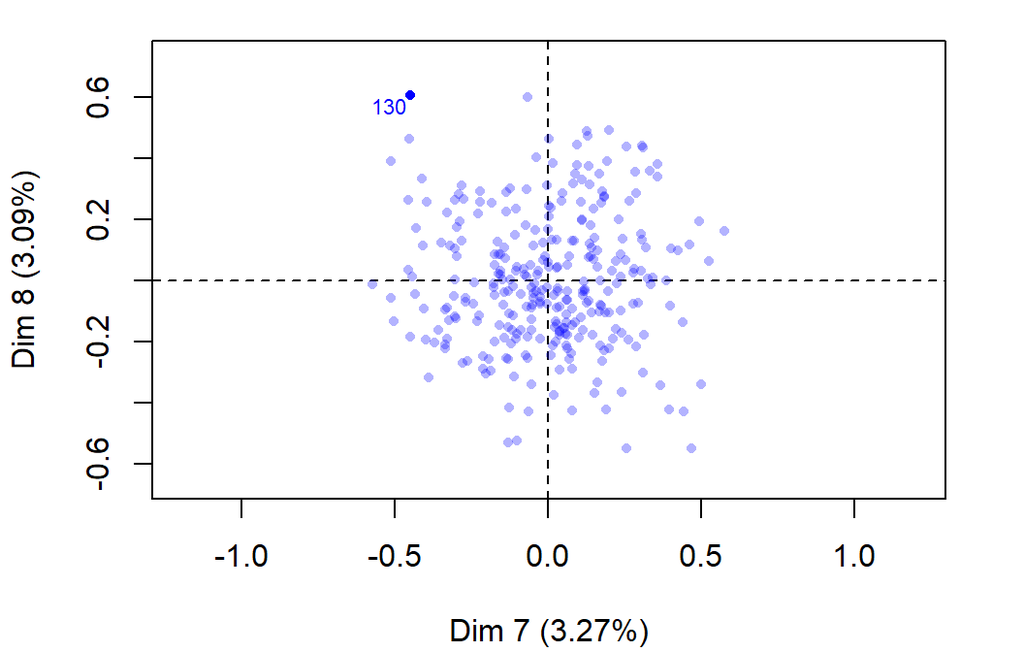

**Figure 6.1 - Individuals factor map (MCA)** *The labeled individuals are those with the higher contribution to the plane construction.*

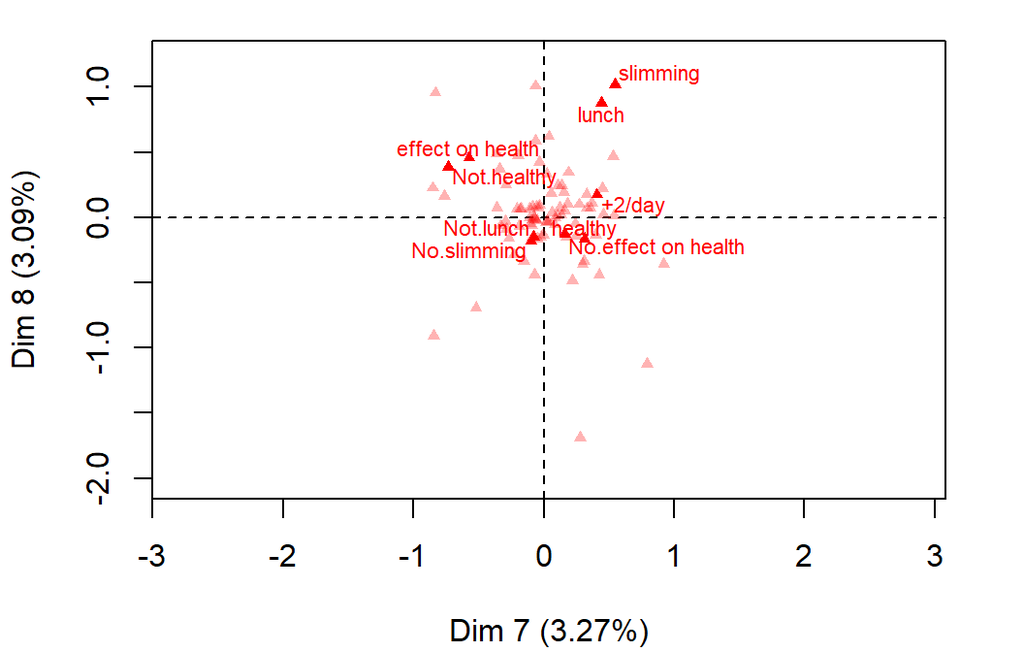

**Figure 6.2 - Variables factor map (MCA)** *The labeled variables are those the best shown on the plane.*

The **dimension 7** opposes individuals characterized by a strongly positive coordinate on the axis (to the right of the graph) to individuals such as *130* (to the left of the graph, characterized by a strongly negative coordinate on the axis).

The group 1 (characterized by a positive coordinate on the axis) is sharing :

- high frequency for factors like *slimming=slimming*, *always=always*, *diuretic=diuretic*, *Sport=sportsman*, *lunch=lunch*, *escape.exoticism=escape-exoticism*, *frequency=+2/day*, *How=milk*, *breakfast=breakfast* and *SPC=senior* (factors are sorted from the most common).
- low frequency for factors like *slimming=No.slimming*, *always=Not.always*, *diuretic=Not.diuretic*, *Sport=Not.sportsman*, *lunch=Not.lunch*, *escape.exoticism=Not.escape-exoticism*, *breakfast=Not.breakfast*, *SPC=employee*, *How=alone* and *tea.time=tea time* (factors are sorted from the rarest).

The group 2 (characterized by a positive coordinate on the axis) is sharing :

- high frequency for factors like *healthy=healthy*, *spirituality=spirituality*, *effect.on.health=No.effect on health*, *how=tea bag+unpackaged*, *relaxing=relaxing*, *dinner=dinner*, *where=chain store+tea shop*, *SPC=employee*, *pub=pub* and *tea.time=Not.tea time* (factors are sorted from the most common).
- low frequency for factors like *healthy=Not.healthy*, *spirituality=Not.spirituality*, *effect.on.health=effect on health*, *age_Q=45-59*, *relaxing=No.relaxing*, *dinner=Not.dinner*, *where=chain store*, *how=tea bag*, *pub=Not.pub* and *frequency=1 to 2/week* (factors are sorted from the rarest).

The group in which the individual *130* stands (characterized by a negative coordinate on the axis) is sharing :

- high frequency for factors like *healthy=Not.healthy*, *breakfast=Not.breakfast*, *slimming=No.slimming*, *tea.time=tea time*, *frequency=1 to 2/week*, *where=chain store*, *friendliness=friendliness*, *Sport=Not.sportsman*, *spirituality=Not.spirituality* and *age_Q=35-44* (factors are sorted from the most common).
- low frequency for factors like *healthy=healthy*, *breakfast=breakfast*, *slimming=slimming*, *frequency=+2/day*, *tea.time=Not.tea time*, *friendliness=Not.friendliness*, *Sport=sportsman*, *spirituality=spirituality*, *sex=M* and *how=tea bag+unpackaged* (factors are sorted from the rarest).

The group 1 (characterized by a positive coordinate on the axis) is sharing :

- high frequency for factors like *slimming=slimming*, *always=always*, *diuretic=diuretic*, *Sport=sportsman*, *lunch=lunch*, *escape.exoticism=escape-exoticism*, *frequency=+2/day*, *How=milk*, *breakfast=breakfast* and *SPC=senior* (factors are sorted from the most common).
- low frequency for factors like *slimming=No.slimming*, *always=Not.always*, *diuretic=Not.diuretic*, *Sport=Not.sportsman*, *lunch=Not.lunch*, *escape.exoticism=Not.escape-exoticism*, *breakfast=Not.breakfast*, *SPC=employee*, *How=alone* and *tea.time=tea time* (factors are sorted from the rarest).

The group 3 (characterized by a negative coordinate on the axis) is sharing :

- high frequency for factors like *healthy=healthy*, *spirituality=spirituality*, *effect.on.health=No.effect on health*, *how=tea bag+unpackaged*, *relaxing=relaxing*, *dinner=dinner*, *where=chain store+tea shop*, *SPC=employee*, *pub=pub* and *tea.time=Not.tea time* (factors are sorted from the most common).
- low frequency for factors like *healthy=Not.healthy*, *spirituality=Not.spirituality*, *effect.on.health=effect on health*, *age_Q=45-59*, *relaxing=No.relaxing*, *dinner=Not.dinner*, *where=chain store*, *how=tea bag*, *pub=Not.pub* and *frequency=1 to 2/week* (factors are sorted from the rarest).

### 7. Description of the plane 9:10

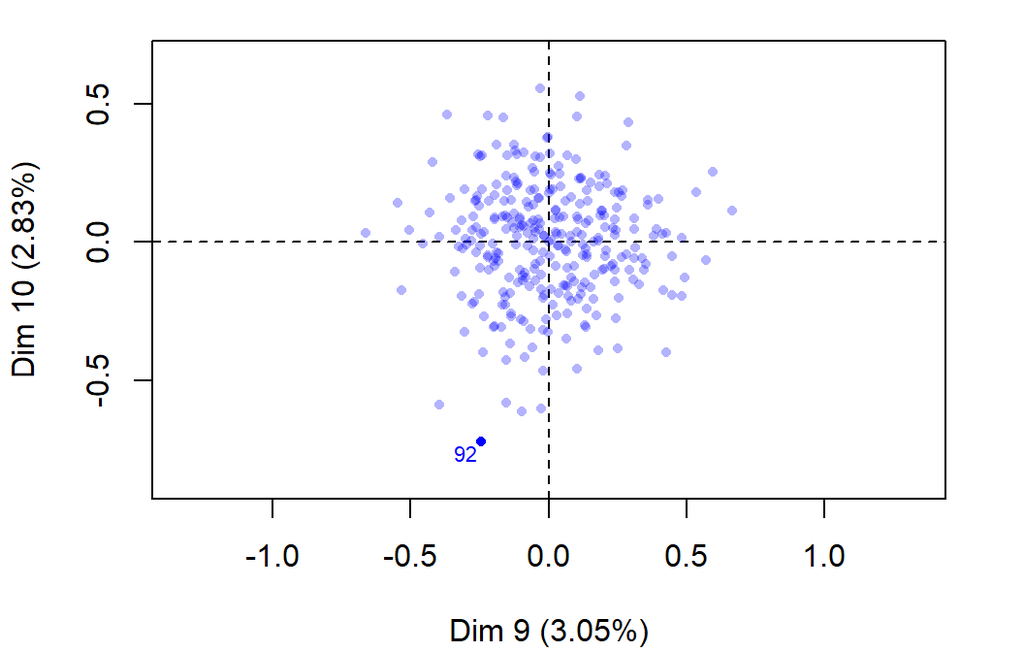

**Figure 7.1 - Individuals factor map (MCA)** *The labeled individuals are those with the higher contribution to the plane construction.*

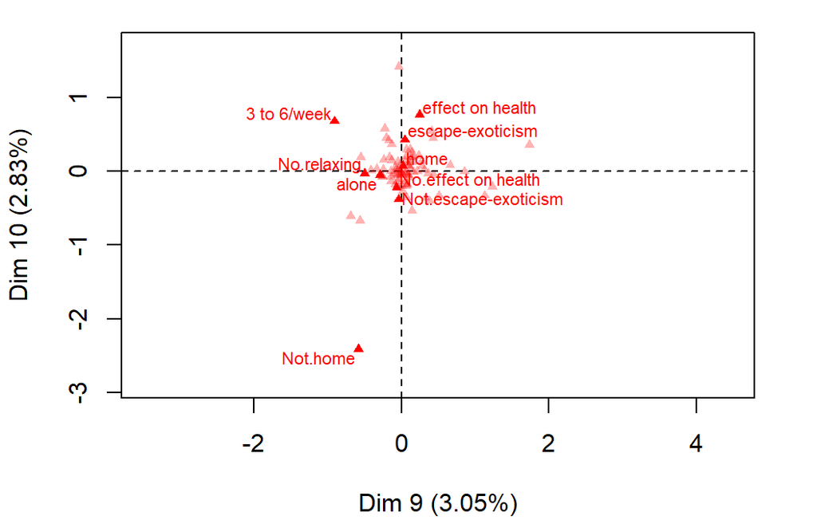

**Figure 7.2 - Variables factor map (MCA)** *The labeled variables are those the best shown on the plane.*

The **dimension 9** opposes individuals characterized by a strongly positive coordinate on the axis (to the right of the graph) to individuals such as *92* (to the left of the graph, characterized by a strongly negative coordinate on the axis).

The group 1 (characterized by a positive coordinate on the axis) is sharing :

- high frequency for factors like *How=milk*, *Tea=black*, *price=p_unknown*, *SPC=other worker*, *slimming=slimming*, *relaxing=relaxing*, *age_Q=35-44*, *how=tea bag*, *sex=M* and *lunch=Not.lunch* (factors are sorted from the most common).
- low frequency for factors like *How=alone*, *slimming=No.slimming*, *relaxing=No.relaxing*, *price=p_variable*, *how=tea bag+unpackaged*, *sex=F*, *lunch=lunch*, *Tea=Earl Grey*, *Tea=green* and *always=Not.always* (factors are sorted from the rarest).

The group 2 (characterized by a negative coordinate on the axis) is sharing :

- high frequency for factors like *frequency=3 to 6/week*, *where=chain store+tea shop*, *escape.exoticism=escape-exoticism*, *resto=Not.resto*, *healthy=Not.healthy*, *evening=Not.evening*, *friendliness=Not.friendliness*, *price=p_variable*, *Tea=Earl Grey* and *slimming=No.slimming* (factors are sorted from the most common).
- low frequency for factors like *escape.exoticism=Not.escape-exoticism*, *resto=resto*, *healthy=healthy*, *evening=evening*, *frequency=1 to 2/week*, *friendliness=friendliness*, *where=chain store*, *slimming=slimming*, *effect.on.health=No.effect on health* and *Tea=black* (factors are sorted from the rarest).

The group in which the individual *92* stands (characterized by a negative coordinate on the axis) is sharing :

- high frequency for factors like *effect.on.health=No.effect on health*, *home=Not.home*, *escape.exoticism=Not.escape-exoticism*, *where=chain store*, *age_Q=25-34*, *evening=evening*, *healthy=healthy*, *Tea=green*, *How=alone* and *lunch=lunch* (factors are sorted from the most common).
- low frequency for factors like *effect.on.health=effect on health*, *where=chain store+tea shop*, *home=home*, *escape.exoticism=escape-exoticism*, *frequency=3 to 6/week*, *evening=Not.evening*, *healthy=Not.healthy*, *age_Q=35-44*, *lunch=Not.lunch* and *friendliness=Not.friendliness* (factors are sorted from the rarest).

The **dimension 10** opposes individuals characterized by a strongly positive coordinate on the axis (to the top of the graph) to individuals such as *92* (to the bottom of the graph, characterized by a strongly negative coordinate on the axis).

The group 1 (characterized by a positive coordinate on the axis) is sharing :

- high frequency for factors like *frequency=3 to 6/week*, *where=chain store+tea shop*, *escape.exoticism=escape-exoticism*, *resto=Not.resto*, *healthy=Not.healthy*, *evening=Not.evening*, *friendliness=Not.friendliness*, *price=p_variable*, *Tea=Earl Grey* and *slimming=No.slimming* (factors are sorted from the most common).
- low frequency for factors like *escape.exoticism=Not.escape-exoticism*, *resto=resto*, *healthy=healthy*, *evening=evening*, *frequency=1 to 2/week*, *friendliness=friendliness*, *where=chain store*, *slimming=slimming*, *effect.on.health=No.effect on health* and *Tea=black* (factors are sorted from the rarest).

The group in which the individual *92* stands (characterized by a negative coordinate on the axis) is sharing :

- high frequency for factors like *effect.on.health=No.effect on health*, *home=Not.home*, *escape.exoticism=Not.escape-exoticism*, *where=chain store*, *age_Q=25-34*, *evening=evening*, *healthy=healthy*, *Tea=green*, *How=alone* and *lunch=lunch* (factors are sorted from the most common).
- low frequency for factors like *effect.on.health=effect on health*, *where=chain store+tea shop*, *home=home*, *escape.exoticism=escape-exoticism*, *frequency=3 to 6/week*, *evening=Not.evening*, *healthy=Not.healthy*, *age_Q=35-44*, *lunch=Not.lunch* and *friendliness=Not.friendliness* (factors are sorted from the rarest).

### 8. Description of the plane 11:12

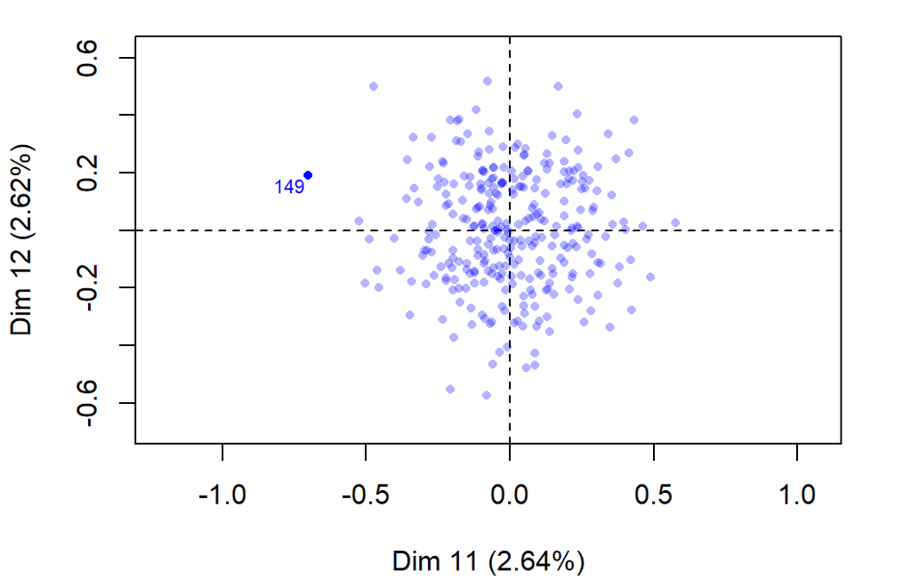

**Figure 8.1 - Individuals factor map (MCA)** *The labeled individuals are those with the higher contribution to the plane construction.*

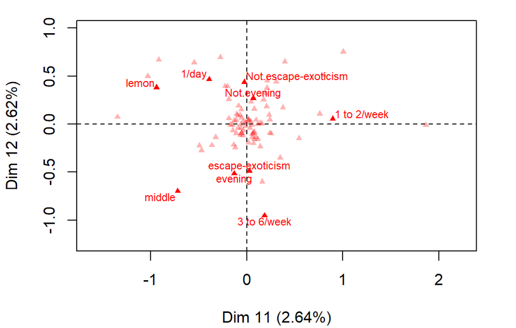

**Figure 8.2 - Variables factor map (MCA)** *The labeled variables are those the best shown on the plane.*

The **dimension 11** opposes individuals characterized by a strongly positive coordinate on the axis (to the right of the graph) to individuals such as *149* (to the left of the graph, characterized by a strongly negative coordinate on the axis).

The group 1 (characterized by a positive coordinate on the axis) is sharing :

- high frequency for factors like *price=p_private label*, *diuretic=diuretic*, *frequency=1 to 2/week*, *friendliness=Not.friendliness*, *SPC=senior*, *SPC=student*, *age_Q=15-24*, *tearoom=tearoom*, *how=tea bag+unpackaged* and *How=other* (factors are sorted from the most common).
- low frequency for factors like *diuretic=Not.diuretic*, *SPC=middle*, *friendliness=friendliness*, *age_Q=25-34*, *How=lemon*, *Tea=Earl Grey*, *tearoom=Not.tearoom*, *how=unpackaged*, *evening=evening* and *Sport=Not.sportsman* (factors are sorted from the rarest).

The group 2 (characterized by a negative coordinate on the axis) is sharing :

- high frequency for factors like *SPC=middle*, *evening=evening*, *escape.exoticism=escape-exoticism*, *How=alone*, *diuretic=Not.diuretic*, *tearoom=Not.tearoom*, *frequency=3 to 6/week*, *dinner=Not.dinner*, *healthy=Not.healthy* and *age_Q=25-34* (factors are sorted from the most common).
- low frequency for factors like *evening=Not.evening*, *escape.exoticism=Not.escape-exoticism*, *diuretic=diuretic*, *SPC=student*, *price=p_private label*, *tearoom=tearoom*, *SPC=senior*, *frequency=1/day*, *How=lemon* and *dinner=dinner* (factors are sorted from the rarest).

The group in which the individual *149* stands (characterized by a negative coordinate on the axis) is sharing :

- high frequency for factors like *How=lemon*, *frequency=1/day*, *where=tea shop*, *relaxing=No.relaxing*, *SPC=non-worker*, *escape.exoticism=Not.escape-exoticism*, *evening=Not.evening*, *Tea=Earl Grey*, *SPC=workman* and *Sport=Not.sportsman* (factors are sorted from the most common).
- low frequency for factors like *How=alone*, *relaxing=relaxing*, *SPC=employee*, *escape.exoticism=escape-exoticism*, *evening=evening*, *frequency=1 to 2/week*, *Tea=black*, *where=chain store*, *Sport=sportsman* and *friendliness=Not.friendliness* (factors are sorted from the rarest).

The **dimension 12** opposes individuals such as *149* (to the top of the graph, characterized by a strongly positive coordinate on the axis) to individuals characterized by a strongly negative coordinate on the axis (to the bottom of the graph).

The group 1 (characterized by a positive coordinate on the axis) is sharing :

- high frequency for factors like *price=p_private label*, *diuretic=diuretic*, *frequency=1 to 2/week*, *friendliness=Not.friendliness*, *SPC=senior*, *SPC=student*, *age_Q=15-24*, *tearoom=tearoom*, *how=tea bag+unpackaged* and *How=other* (factors are sorted from the most common).
- low frequency for factors like *diuretic=Not.diuretic*, *SPC=middle*, *friendliness=friendliness*, *age_Q=25-34*, *How=lemon*, *Tea=Earl Grey*, *tearoom=Not.tearoom*, *how=unpackaged*, *evening=evening* and *Sport=Not.sportsman* (factors are sorted from the rarest).

The group in which the individual *149* stands (characterized by a positive coordinate on the axis) is sharing :

- high frequency for factors like *How=lemon*, *frequency=1/day*, *where=tea shop*, *relaxing=No.relaxing*, *SPC=non-worker*, *escape.exoticism=Not.escape-exoticism*, *evening=Not.evening*, *Tea=Earl Grey*, *SPC=workman* and *Sport=Not.sportsman* (factors are sorted from the most common).
- low frequency for factors like *How=alone*, *relaxing=relaxing*, *SPC=employee*, *escape.exoticism=escape-exoticism*, *evening=evening*, *frequency=1 to 2/week*, *Tea=black*, *where=chain store*, *Sport=sportsman* and *friendliness=Not.friendliness* (factors are sorted from the rarest).

The group 3 (characterized by a negative coordinate on the axis) is sharing :

- high frequency for factors like *SPC=middle*, *evening=evening*, *escape.exoticism=escape-exoticism*, *How=alone*, *diuretic=Not.diuretic*, *tearoom=Not.tearoom*, *frequency=3 to 6/week*, *dinner=Not.dinner*, *healthy=Not.healthy* and *age_Q=25-34* (factors are sorted from the most common).
- low frequency for factors like *evening=Not.evening*, *escape.exoticism=Not.escape-exoticism*, *diuretic=diuretic*, *SPC=student*, *price=p_private label*, *tearoom=tearoom*, *SPC=senior*, *frequency=1/day*, *How=lemon* and *dinner=dinner* (factors are sorted from the rarest).

### 9. Description of the dimension 13

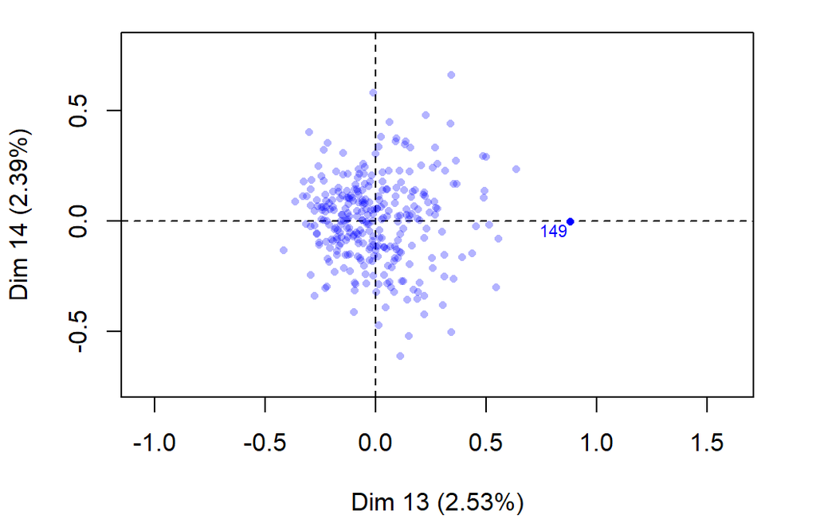

**Figure 9.1 - Individuals factor map (MCA)** *The labeled individuals are those with the higher contribution to the plane construction.*

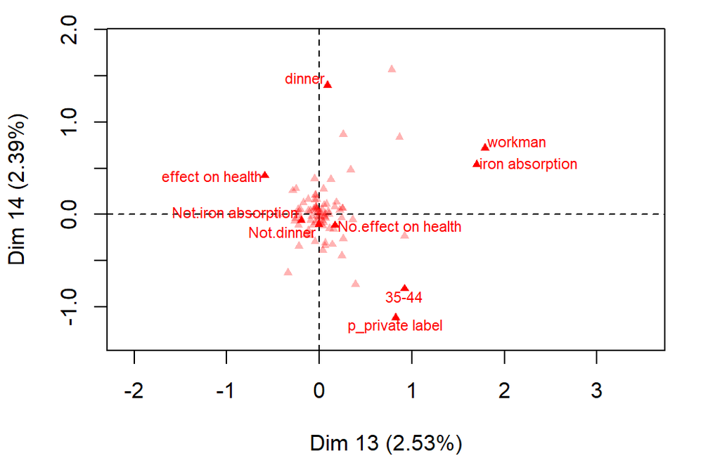

**Figure 9.2 - Variables factor map (MCA)** *The labeled variables are those the best shown on the plane.*

The **dimension 13** opposes individuals such as *149* (to the right of the graph, characterized by a strongly positive coordinate on the axis) to individuals characterized by a strongly negative coordinate on the axis (to the left of the graph).

The group in which the individual *149* stands (characterized by a positive coordinate on the axis) is sharing :

- high frequency for the factors *iron.absorption=iron absorption*, *frequency=3 to 6/week*, *effect.on.health=No.effect on health*, *SPC=student*, *healthy=healthy*, *SPC=workman* and *spirituality=Not.spirituality* (factors are sorted from the most common).
- low frequency for the factors *iron.absorption=Not.iron absorption*, *effect.on.health=effect on health*, *SPC=employee*, *healthy=Not.healthy*, *How=milk*, *how=tea bag+unpackaged* and *spirituality=spirituality* (factors are sorted from the rarest).

The group 2 (characterized by a negative coordinate on the axis) is sharing :

- high frequency for factors like *effect.on.health=effect on health*, *iron.absorption=Not.iron absorption*, *Sport=sportsman*, *age_Q=25-34*, *dinner=dinner*, *How=other*, *escape.exoticism=escape-exoticism*, *frequency=1/day*, *pub=pub* and *lunch=Not.lunch* (factors are sorted from the most common).
- low frequency for factors like *age_Q=35-44*, *effect.on.health=No.effect on health*, *iron.absorption=iron absorption*, *How=lemon*, *Sport=Not.sportsman*, *price=p_private label*, *dinner=Not.dinner*, *Tea=green*, *escape.exoticism=Not.escape-exoticism* and *pub=Not.pub* (factors are sorted from the rarest).

The group 3 (characterized by a negative coordinate on the axis) is sharing :

- high frequency for factors like *sugar=sugar*, *iron.absorption=Not.iron absorption*, *spirituality=spirituality*, *Tea=green*, *resto=Not.resto*, *Sport=Not.sportsman*, *How=milk*, *frequency=1 to 2/week*, *dinner=Not.dinner* and *always=always* (factors are sorted from the most common).
- low frequency for factors like *sugar=No.sugar*, *iron.absorption=iron absorption*, *How=alone*, *spirituality=Not.spirituality*, *resto=resto*, *Sport=sportsman*, *dinner=dinner*, *always=Not.always*, *effect.on.health=effect on health* and *age_Q=25-34* (factors are sorted from the rarest).

### 10. Classification

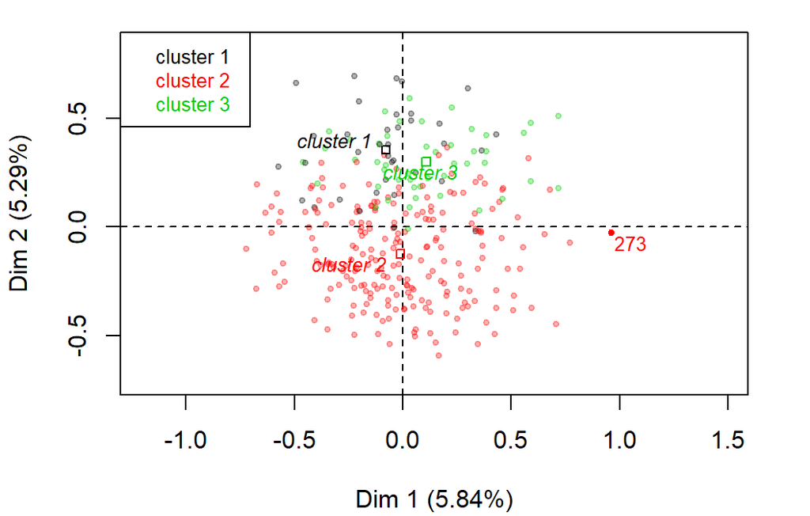

**Figure 10 - Ascending Hierarchical Classification of the individuals.** *The classification made on individuals reveals 3 clusters.*

The cluster 1 is made of individuals sharing :

- high frequency for the factors *where=tea shop*, *how=unpackaged*, *price=p_upscale*, *sophisticated=sophisticated*, *SPC=middle*, *sex=M*, *Tea=green*, *age_Q=25-34*, *resto=Not.resto* and *dinner=dinner* (factors are sorted from the most common).
- low frequency for factors like *where=chain store*, *how=tea bag*, *age_Q=15-24*, *price=p_branded*, *sophisticated=Not.sophisticated*, *sex=F*, *where=chain store+tea shop*, *Tea=Earl Grey*, *how=tea bag+unpackaged* and *price=p_variable* (factors are sorted from the rarest).

The cluster 3 is made of individuals sharing :

- high frequency for factors like *SPC=non-worker*, *age_Q=+60*, *work=Not.work*, *Sport=Not.sportsman*, *always=Not.always*, *evening=Not.evening*, *Tea=black*, *feminine=feminine*, *where=chain store+tea shop* and *sex=F* (factors are sorted from the most common).
- low frequency for factors like *age_Q=15-24*, *work=work*, *SPC=student*, *age_Q=25-34*, *Sport=sportsman*, *SPC=employee*, *Tea=Earl Grey*, *evening=evening*, *always=always* and *feminine=Not.feminine* (factors are sorted from the rarest).